# Some Calculations of Effective Population Size

October 29 2015

### Background

Effective population size is a widely used concept - Charlesworth (2009) has written an excellent introduction to the subject. Furthermore, in Table 3 of that paper (below) he summarizes some estimates made of Ne based on nucleotide sequence data. We will work through a couple of those examples.

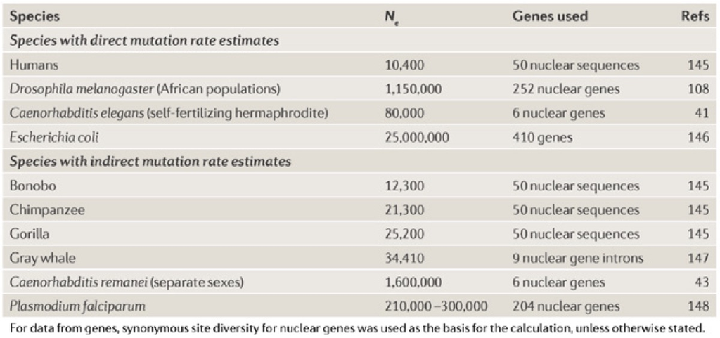

### Humans and Apes

The question of the effective population sizes of humans and the great apes was considered by Yu (2004) in a fairly straightforward way, using the Tajima estimator to do so:

π = 4Neμ

It takes only trivial algebraic rearrangement to recognize that

Ne = π/4μ

We can calculate π from nucleotide sequence data; the question is what to use for μ. One very approximate way to get at that would be to divide the percent divergence between to species by 2t, where t is the estimated time of divergence. We can do that for humans and chimpanzees as follows:

```r
td <-6000000
nucdiv <- .0129
mu <-nucdiv/(2*td)
mu
```

```
## [1] 1.075e-09
```

Note that this is a yearly mutation rate; to get the per generation rate, we need to multiply it by the average number of years per generation (20 in humans):

```r
mu.hum <-mu*20
```

```r
pi.hum <-.00087
n.hum <-pi.hum/(4*mu.hum)
n.hum
```

```
## [1] 10116.28
```

And we come up with the surprisingly low figure of 10116 (note that the estimate of μ they used was slightly different, as it was calculated based on divergence among gorillas, chimpanzees and humans, not just the latter two taxa).

References

Charlesworth J., 2006 The rate of adaptive evolution in enteric bacteria. Molecular Biology and Evolution **23**: 1348–1356.

Charlesworth B., 2009 Fundamental concepts in genetics: Effective population size and patterns of molecular evolution and variation. Nat Rev Genet **10**: 195–205.

Yu N., 2004 Nucleotide diversity in gorillas. Genetics **166**: 1375–1383.